# Part II - (Main Findings of Ford GoBike System Data Exploration)

## by Som Patrick

## Investigation Overview

> In this investigation, I wanted to look at the various genders available in the dataset and their correspondening user types in their respective numbers. The main focus was on the the member_gender and the user_type columns.

## Dataset Overview

> There are 183412 bikes in the dataset with 16 features ('duration_sec', 'start_time', 'end_time', 'start_station_id', 'start_station_name', 'start_station_latitude', 'start_station_longitude', 'end_station_id', 'end_station_name', 'end_station_latitude', 'end_station_longitude', 'bike_id', 'user_type', 'member_birth_year', 'member_gender', 'bike_share_for_all_trip').

Some data points were removed from the analysis due to inconsistencies or missing information

### Composition of the various genders in the dataset

Out of the total number of people(174952), 130500 are males , 40805 are females and 3647 are Other.i.e consider themselves as neigher male nor female.The visualization below depicts this data.

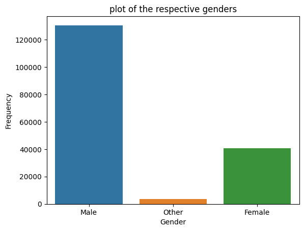

### Types of users of the biking service.

In this part of the visualization, I wanted to find out the different types of users of the biking service. There are two types of users: Subscribers and Customers. A larger number of the were subscribers.

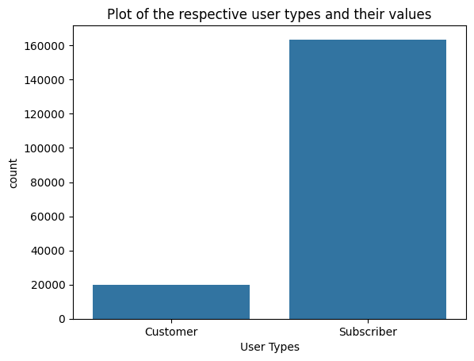

### Percentage of the respective user types.

Subcribers made up about 90.53% of the users.i.e the majority and Customers made up the smallest percentage 9.47%

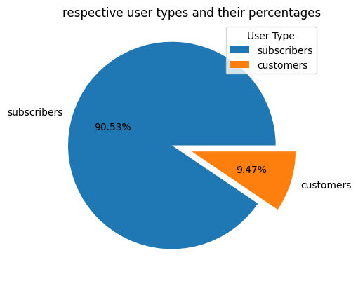

### The various genders and their corresponding user types

Out of a total number of 40805 females, 4623 of them are customers and 36182 are subscribers.Also 11493 and 119007 are males customers and subscribers respectively. Lastly, 3647 people are categorized as other genders, with 450 of them being customers and 3197 being subscribers.

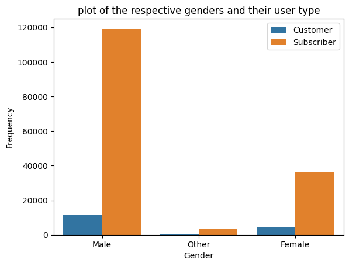